# Elastic Functional Bayesian Model Calibration

Example notebook demonstrating workflow for EFBMC. We will demonstrate this method calibrating one experiment from a Z-machine experiment in which we want to know the parameters of the Equation of State Model of Platinum.

Code locations are availble below:

1. [impala](https://github.com/lanl/impala/)
2. [fdasrvf](https://github.com/jdtuck/fdasrsf_python)
3. [mvBayes](https://github.com/sandialabs/mvBayesPy)
4. [pyBASS](https://github.com/lanl/pyBASS.git)

Other surrogate models:

1. pyBayesPPR
2. stochtree

For questions please contact

J. Derek Tucker  
Statistical Sciences - 5573  
jdtuck@sandia.gov  
505-284-8415

[figure not shown]

First we need to import the required packages

```python
import os
os.environ["VECLIB_MAXIMUM_THREADS"] = "1"
os.environ["OMP_NUM_THREADS"] = "1"
os.environ["MKL_NUM_THREADS"] = "1"
os.environ["OPENBLAS_NUM_THREADS"] = "1"
os.environ["NUMEXPR_NUM_THREADS"] = "1"

import numpy as np
from impala import superCal as sc
import matplotlib.pyplot as plt
import matplotlib.cm as cm
import pyBASS as pb
import mvBayes as mb
import fdasrsf as fs
import seaborn as sns
import arviz as az
import pandas as pd
from scipy.interpolate import Akima1DInterpolator

n_cores=os.cpu_count()
```

## Data Pre-processing

Next we load in the training data from the computer model and extract the simulation parameters. We will also set a path to save the results

```python
data_path = '/Users/jdtuck/Documents/Data/zbmc'
sim_time = np.genfromtxt(data_path + '/PlatinumBMC_May2023/Vinet/build1/time.out')
simulations = np.genfromtxt(data_path + '/PlatinumBMC_May2023/Vinet/build1/lhs_10000bp_5500res.txt',skip_header=1)

a = np.array([2,3,4,5,6,7,8,9,10,11])
sim_variables = simulations[:,a]
p = sim_variables.shape[1]

dir = data_path + '/PlatinumBMC_May2023/Vinet/impala_id_exp1'
if not os.path.exists(dir):
    os.mkdir(dir)
save_fn = dir + '/platinum_id_exp1'
```

Next we will load in the experiment we wish to calibrate

```python
exp1 = np.genfromtxt(data_path + '/PlatinumBMC_May2023/Vinet/suite/Z2765/Z2765S2AvgTrueTrim.dat')
```

```python
M1 = 0
N1 = 500
M = 100
time_new = np.linspace(sim_time[M1], sim_time[N1-1], M)
f_sim = np.zeros((M,simulations.shape[0]))
for i in range(simulations.shape[0]):
    f_i = Akima1DInterpolator(sim_time[M1:N1], simulations[i,(M1+a[-1]+1):(N1+a[-1]+1)])
    f_sim[:,i] = f_i(time_new)

f_i = Akima1DInterpolator(exp1[:,0], exp1[:,1])
f_exp = f_i(time_new)
```

Look at the original data with the experiment overlaid

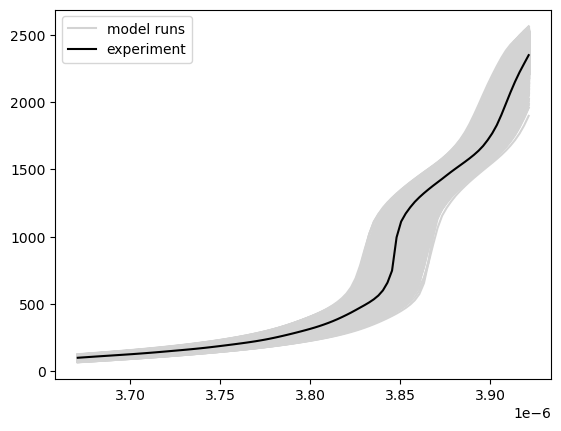

```python
plt.plot(time_new, f_sim, color='lightgrey')
plt.plot(time_new, f_exp, color='black')
plt.legend(['model runs','experiment'])
ax = plt.gca()
leg = ax.get_legend()
leg.legend_handles[0].set_color('lightgrey')
leg.legend_handles[1].set_color('black');
plt.savefig(save_fn + 'original.png', dpi=300, transparent=True)
```

## Elastic Functional Alignment

We will now align the computer model output to the experiment. We will need the aligned data `ftilde_train` and the shooting vectors `vv_train`. Additionally we will need the shooting vector for the experiment. In this case, since we are aligning to the experiment warping function will be identity ($\gamma_{id}$) and then the corresponding shooting vector `vv_obs`.

There is the option of the parameter `lam` in `multiple_align_functions` that restricts the amount of alignment. In some cases we will set this to a small value (e.g., 0.01) to remove heteroskedacity from the warping functions.

```python
tt = np.linspace(0,1,M)
out = fs.fdawarp(f_sim, tt)
out.multiple_align_functions(f_exp, parallel=True)
gam_train = out.gam
vv_train = fs.geometry.gam_to_psi(gam_train)
ftilde_train = out.fn
qtilde_train = out.qn

gam_obs = np.linspace(0, 1, M)
vv_obs = fs.geometry.gam_to_psi(gam_obs)
```

We will now plot the alignment results. First is the aligned functions.

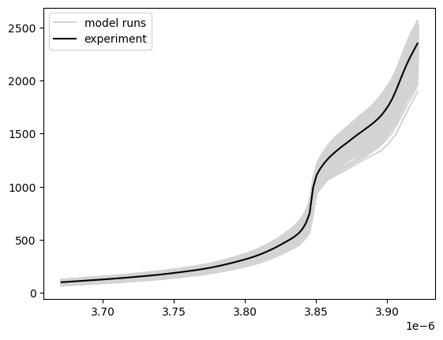

```python
plt.plot(time_new, ftilde_train, color='lightgrey')
plt.plot(time_new, f_exp, color='black')
plt.legend(['model runs','experiment'])
ax = plt.gca()
leg = ax.get_legend()
leg.legend_handles[0].set_color('lightgrey')
leg.legend_handles[1].set_color('black');
plt.savefig(save_fn + 'ftilde_train.png', dpi=300, transparent=True)
```

Then the corresponding warping functions

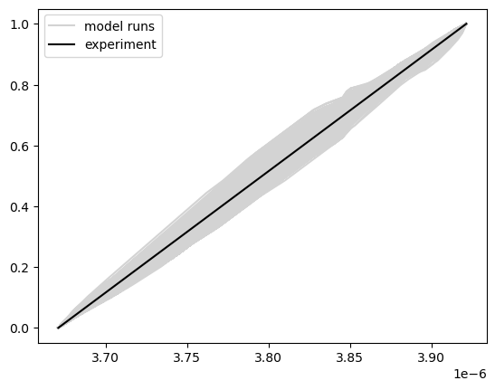

```python
plt.plot(time_new, gam_train, color='lightgrey')
plt.plot(time_new, gam_obs, color='black')
plt.legend(['model runs','experiment'])
ax = plt.gca()
leg = ax.get_legend()
leg.legend_handles[0].set_color('lightgrey')
leg.legend_handles[1].set_color('black');
plt.savefig(save_fn + 'gam_train.png', dpi=300, transparent=True)
```

and the corresponding shooting vectors

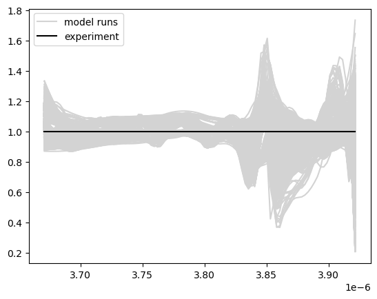

```python
plt.plot(time_new, vv_train, color='lightgrey')
plt.plot(time_new, vv_obs, color='black')
plt.legend(['model runs','experiment'])
ax = plt.gca()
leg = ax.get_legend()
leg.legend_handles[0].set_color('lightgrey')
leg.legend_handles[1].set_color('black');
plt.savefig(save_fn + 'v_train.png', dpi=300, transparent=True)
```

## Surrogate Model Fitting

Next, we will fit the BASS surrogate to the computer model and evaluate its performance. We use the `mvBayes` package due to its ability to introspect surrogates and their performance.

The choice of `nBasis` here is made from exploratory data analysis. It can also be chosen based on the percentage of variance explained from the functional principal component analysis (fPCA) decomposition. The parameter in `mvBayes` do perform this is `propVarExplained`.

The parameter `idxSamplesArg` sets which parameter the emulator (BASS) uses to pick mcmc samples for prediction. In this case the parameter is `mcmc_use`.

We also optional tell `mvBayes` to extract the residual standard deviation from the `s2` samples since BASS provides it. If the chosen emulator does not provide, `mvBayes` will estimate it.

```python
emu_ftilde = mb.mvBayes(pb.bass,
                        sim_variables,
                        ftilde_train.T,
                        idxSamplesArg='mcmc_use',
                        nCores=n_cores,
                        # optionally extract posterior samples of residual standard deviation
                        residSDExtract = lambda bass_out: np.sqrt(bass_out.samples.s2) )

emu_vv = mb.mvBayes(pb.bass,
                    sim_variables,
                    vv_train.T,
                    basisType="pns",
                    idxSamplesArg='mcmc_use',
                    nCores=n_cores,
                    # optionally extract posterior samples of residual standard deviation
                    residSDExtract = lambda bass_out: np.sqrt(bass_out.samples.s2) )
```

```
Starting mvBayes with 5 components, using 5 cores.
BASS MCMC Complete. Time: 1.243499 seconds.
BASS MCMC Complete. Time: 1.331426 seconds.
BASS MCMC Complete. Time: 1.418568 seconds.
BASS MCMC Complete. Time: 1.423957 seconds.
BASS MCMC Complete. Time: 1.642593 seconds.
Initial PNS subsphere dimension: 16

Percentage of variability in PNS sequence 99.990000
dataset is on 15-sphere
.. Check that the following holds: 15 = 15
Starting mvBayes with 6 components, using 6 cores.
BASS MCMC Complete. Time: 1.461970 seconds.
BASS MCMC Complete. Time: 1.485329 seconds.
BASS MCMC Complete. Time: 1.622969 seconds.
BASS MCMC Complete. Time: 1.770907 seconds.
BASS MCMC Complete. Time: 1.873377 seconds.
BASS MCMC Complete. Time: 1.201563 seconds.
```

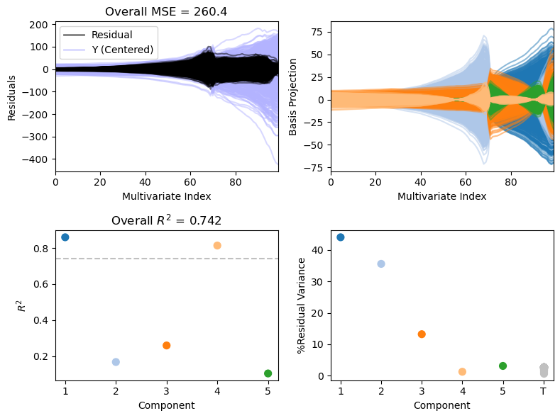

```python
emu_ftilde.plot()
```

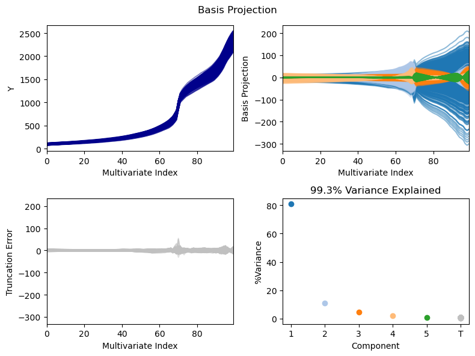

```python
emu_ftilde.basisInfo.plot()
```

Lets evaluate the shooting vector emulator

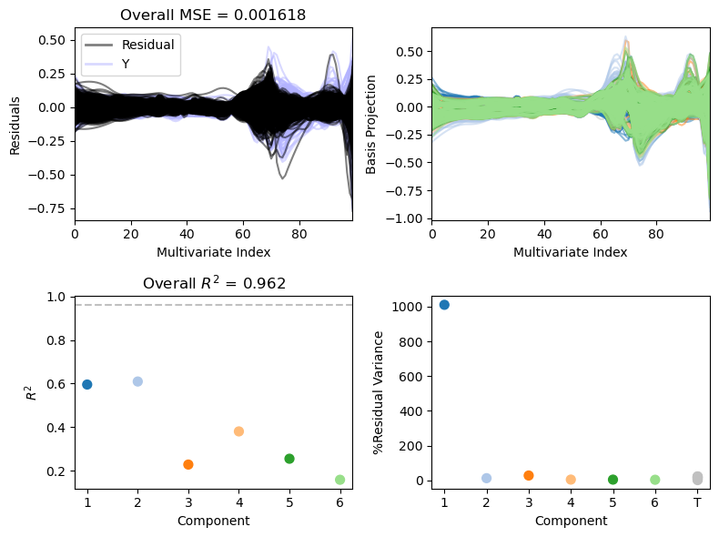

```python
emu_vv.plot()
```

## Bayesian Model Calibration

We will now set up `impala` to perform the calibration. First we need to setup the parameter names and bounds on the parameters. `impala` sets uniform priors on the parameters based on their bounds.

```python
input_names = ['rho','B0','BP0','Y0','A','floort','sampt','dt','ucon','ulin']
bounds_mat = np.array([[sim_variables[:,i].min(), sim_variables[:,i].max()] for i in range(p)])
bounds = dict(zip(input_names, bounds_mat))
```

We will now set up the calibration object and add the experimental data for the aligned data and shooting vectors. `impala` is set up to run multiple chains and do annealing so we set up a temperature ladder of 20 chains. We also set the chains to run for 4000 samples with a burn in of 2000 samples. The last line runs the calibration.

```python
setup = sc.CalibSetup(bounds, constraint_func="bounds")
model_ftilde = sc.ModelmvBayes(emu_ftilde, input_names) # for aligned data
model_vv = sc.ModelmvBayes(emu_vv, input_names) # for warping functions
setup.addVecExperiments(f_exp,
    model_ftilde,
    sd_est=np.array([0.001]),
    s2_df=np.array([20.]),
    s2_ind=np.array([0]*M))
setup.addVecExperiments(vv_obs,
    model_vv,
    sd_est=np.array([0.1]),
    s2_df=np.array([20.]),
    s2_ind=np.array([0]*M))
setup.setTemperatureLadder(1.05**np.arange(20))
setup.setMCMC(4000,2000,1,10)
out = sc.calibPool(setup)
```

```
[2026-06-02 12:34:50 | 3999/3999 (100%) | WALL: 0:00:58 | ETA: 0:00:00 | 68.55it/s]
Calibration MCMC Complete. Time: 58.353169 seconds.
```

```python
uu = np.arange(2000, 4000, 2)

theta_dict = sc.tran_unif(out.theta[uu,0,:], setup.bounds_mat, setup.bounds.keys())
ftilde_pred_obs = setup.models[0].eval(theta_dict)
vv_pred_obs = setup.models[1].eval(theta_dict)
gam_pred_obs = fs.geometry.psi_to_gam(vv_pred_obs.T)
```

Now we will look at the likelihood and chains to make sure the MCMC chains are stable and have converged.

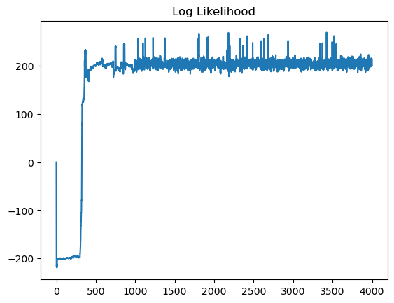

```python
plt.plot(out.llik)
plt.title('Log Likelihood')
plt.savefig(save_fn + 'platinum_llike.png', dpi=300)
```

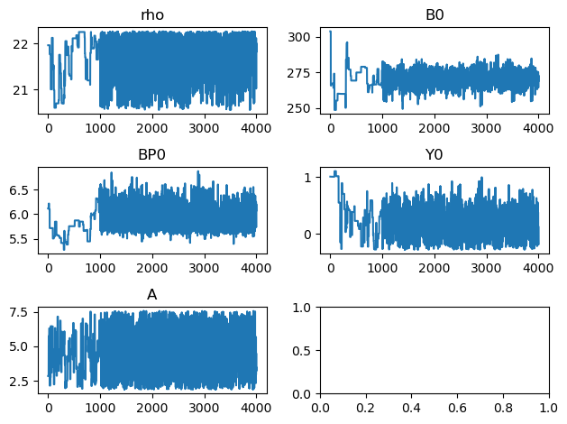

```python
input_names2 = [ input_names[i] for i in [0, 1, 2, 3, 4] ]
nplots = len(input_names2)
ns1 = int(np.ceil(np.sqrt(nplots)))
ns2 = int(np.round(np.sqrt(nplots)))
fig, axs = plt.subplots(ns1, ns2)
for i, ax in enumerate(fig.axes):
    if i < nplots:
        ax.plot(out.theta_native[input_names2[i]])
        ax.set(title=input_names2[i])
plt.tight_layout()
plt.savefig(save_fn + 'platinumnp_chains.png', dpi=300)
```

Next we will look at convergence diagnostics of ESS and $\hat{R}$

```python
dataset = az.convert_to_inference_data(np.transpose(out.theta[uu,:,:], (1,0,2)))
ess = az.ess(dataset)
ess
```

```
<xarray.Dataset> Size: 160B
Dimensions:  (x_dim_0: 10)
Coordinates:
  * x_dim_0  (x_dim_0) int64 80B 0 1 2 3 4 5 6 7 8 9
Data variables:
    x        (x_dim_0) float64 80B 6.81e+03 7.747e+03 ... 1.336e+04 4.464e+03
Attributes:
    created_at:     2026-06-02T18:35:15.715073+00:00
    arviz_version:  0.23.4
```

```python
rhat = az.rhat(dataset)
rhat
```

```
<xarray.Dataset> Size: 160B
Dimensions:  (x_dim_0: 10)
Coordinates:
  * x_dim_0  (x_dim_0) int64 80B 0 1 2 3 4 5 6 7 8 9
Data variables:
    x        (x_dim_0) float64 80B 1.003 1.012 1.003 1.005 ... 1.004 1.001 1.007
Attributes:
    created_at:     2026-06-02T18:35:15.715073+00:00
    arviz_version:  0.23.4
```

Examine the pair plot of the parameters. The diagonal contains the posterior distributions of the parameters. The off diagonal is the dependence. The dots are colored by how they appear in the chain (blue is early and red is late). This also helps determine if the chains are mixing well.

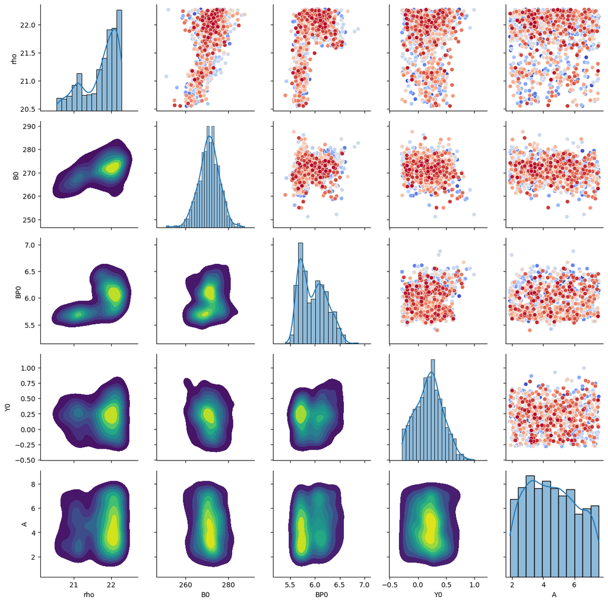

```python
dat = pd.DataFrame(out.theta_native)
dat = dat[input_names2]
dat = dat.loc[uu,:]
dat.insert(0,'idx',dat.index,allow_duplicates = False)
g = sns.PairGrid(dat.loc[:, dat.columns != 'idx'], diag_sharey=False);
g.map_upper(sns.scatterplot, palette = 'coolwarm', hue=dat['idx'], legend=False);
g.map_lower(sns.kdeplot, cmap="viridis", fill=True, thresh=0.05);
g.map_diag(sns.histplot, kde=True);
plt.savefig(save_fn + 'pair_plot.png', dpi=300)
```

Next we are going to evaluate the surrogate model at the calibrate parameters for the entire posterior distribution. They gray curves are the computer model, blue curves are the calibrated surrogate curves, and black is the experiment.

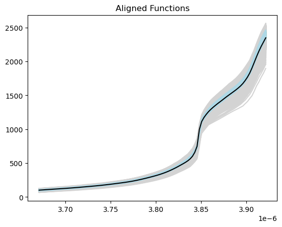

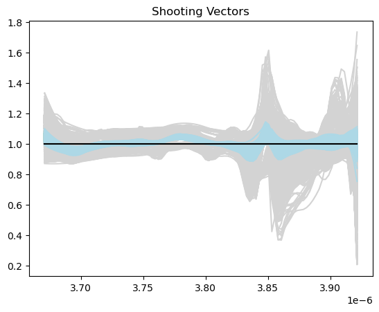

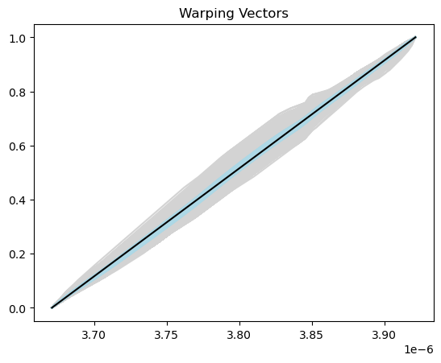

```python
M1 = 0
N1 = 500
time_new = np.linspace(sim_time[M1], sim_time[N1 - 1], M)

plt.figure()
plt.plot(time_new, ftilde_train, color="lightgrey")
plt.plot(time_new, ftilde_pred_obs.T, color="lightblue")
plt.plot(time_new, f_exp, color="black")
plt.title('Aligned Functions')
plt.savefig(save_fn + "ftilde_cal_exp.png", dpi=300)

plt.figure()
plt.plot(time_new, vv_train, color="lightgrey")
plt.plot(time_new, vv_pred_obs.T, color="lightblue")
plt.plot(time_new, vv_obs, color="black")
plt.title('Shooting Vectors')
plt.savefig(save_fn + "v_cal.png", dpi=300)

plt.figure()
plt.plot(time_new, gam_train, color="lightgrey")
plt.plot(time_new, gam_pred_obs, color="lightblue")
plt.plot(time_new, gam_obs, color="black")
plt.title('Warping Vectors')
plt.savefig(save_fn + "gam_cal.png", dpi=300)
```

We then combine the outputs of the emulators via composition to look at in the original data space

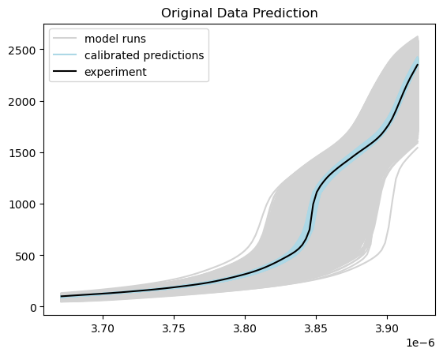

```python
obspred_all = np.zeros([len(uu), M])
for i in range(len(uu)):
    obspred_all[i, :] = fs.warp_f_gamma(
        tt, ftilde_pred_obs[i, :], fs.invertGamma(gam_pred_obs[:, i])
    )

plt.plot(time_new, f_sim, color="lightgrey")
plt.plot(time_new, obspred_all.T, color="lightblue")
plt.plot(time_new, f_exp, color="black")
plt.title("Original Data Prediction")
plt.legend(["model runs", "calibrated predictions", "experiment"])
ax = plt.gca()
leg = ax.get_legend()
leg.legend_handles[0].set_color("lightgrey")
leg.legend_handles[1].set_color("lightblue")
leg.legend_handles[2].set_color("black")
plt.savefig(save_fn + "calibration.png", dpi=300)
```

## Sensitivity Analysis

We can also perform sensitivity analysis on the surrogate through `mvBayes` by doing the following. The BASS emulator has a closed form sobol indices and we will utilize that. `mvBayes` also provides the ability to monte carlo to determine the sobol indices.

First we will look at the amplitude surrogate

```
Start

Integrating: 0.01s

Shuffling: 30.88s

Finish: 30.93s
```

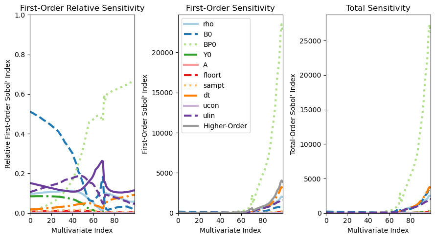

```python
emu_ftilde.mvSobol(idxSamplesArg='mcmc_use') # 'mcmc_use' is bppr's equivalent of idxSamples
emu_ftilde.plotSobol(labels=input_names)
```

Next the phase surrogate

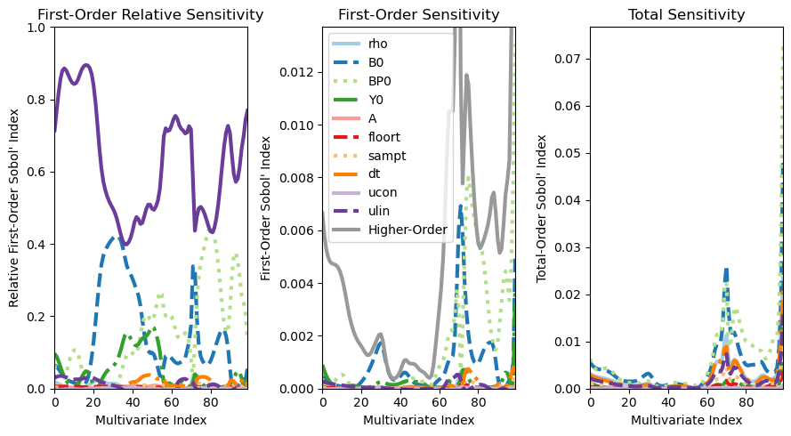

```python
emu_vv.mvSobol(idxSamplesArg='mcmc_use') # 'mcmc_use' is bppr's equivalent of idxSamples
emu_vv.plotSobol(labels=input_names)
```

We can also look at sensitivity as a functional boxplot or waterfall plot

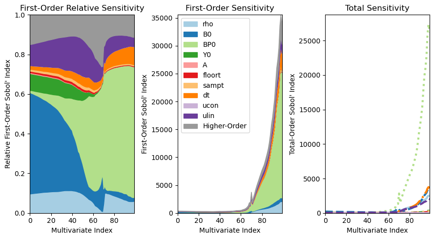

```python
emu_ftilde.plotSobol(labels=input_names, waterfall=True)
```

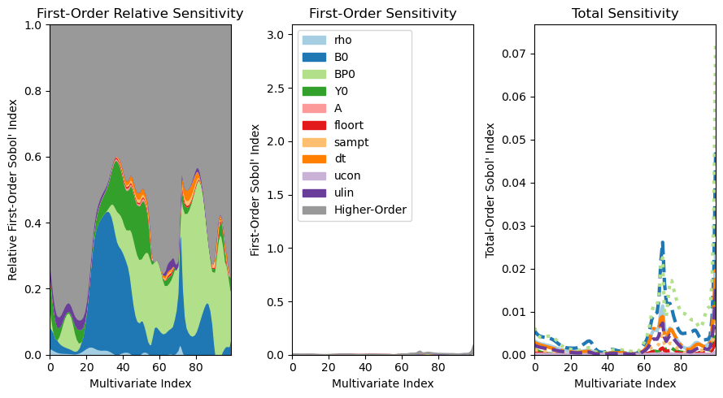

```python
emu_vv.plotSobol(labels=input_names, waterfall=True)
```